# Demo yellowbrick

```python
%matplotlib inline
import numpy as np
import pandas as pd
from sklearn import cluster
import yellowbrick
import arcgis
```

## Load Test Data

The data include descriptions of hypothetical samples corresponding to 23 species of gilled mushrooms in the Agaricus and Lepiota Family. Each species was identified as definitely edible, definitely poisonous, or of unknown edibility and not recommended (this latter class was combined with the poisonous one).

Our data contains information for 3 nominally valued attributes and a target value from 8124 instances of mushrooms (4208 edible, 3916 poisonous).

```python
from yellowbrick.datasets import load_mushroom

X, y = load_mushroom()
pd.DataFrame(X).head() # inspect the first five rows
```

|  | shape | surface | color |
| --- | --- | --- | --- |
| 0 | convex | smooth | yellow |
| 1 | bell | smooth | white |
| 2 | convex | scaly | white |
| 3 | convex | smooth | gray |
| 4 | convex | scaly | yellow |

## Feature Extraction

#### Issues

- Our data is categorical

#### Solution

Use scikit-learn to transform the data using the `OneHotEncoder`.

```python
from sklearn.pipeline import Pipeline
from sklearn.preprocessing import OneHotEncoder, LabelEncoder
```

```
# Label-encode targets before modeling
y = LabelEncoder().fit_transform(y)

# One-hot encode columns before modeling
model = Pipeline([
 ('one_hot_encoder', OneHotEncoder()),
 ('estimator', estimator)
])
```

## Modeling and Evaluation

For our categorical data, we can use common metrics to evaluate the classifiers used in this `example`.

- **Precision** - is the number of correct positive results divided by the number of all positive results
- **Recall** - is the number of correct positive results divided by the number of positive results that should have been returned
- **F1 Score** - is a measure of a test's accuracy. It uses the precision and recall to compute the score.
  - The **F1** score can be interpreted as a weight of average of precision and recall
  - Best value is 1 and worst value is 0

**Equation**

```
precision = true positives / (true positives + false positives)

recall = true positives / (false negatives + true positives)

F1 score = 2 * ((precision * recall) / (precision + recall))
```

```python
from sklearn.svm import LinearSVC, NuSVC, SVC
from sklearn.metrics import f1_score, recall_score, precision_score
from sklearn.neighbors import KNeighborsClassifier
from sklearn.linear_model import (LogisticRegressionCV,
                                  LogisticRegression,
                                  SGDClassifier)
from sklearn.ensemble import (BaggingClassifier,
                              ExtraTreesClassifier,
                              RandomForestClassifier)
```

```python
import warnings
warnings.simplefilter('ignore')
models = [
    SVC(gamma='auto'), NuSVC(gamma='auto'), LinearSVC(),
    SGDClassifier(max_iter=10, tol=1e-3), KNeighborsClassifier(),
    LogisticRegression(solver='lbfgs',  max_iter=300),
    LogisticRegressionCV(cv=3),
    BaggingClassifier(), ExtraTreesClassifier(n_estimators=300),
    RandomForestClassifier(n_estimators=300)
]
```

```python
def score_model(X, y, estimator, **kwargs):
    """
    Test various estimators.
    """
    y = LabelEncoder().fit_transform(y)
    model = Pipeline([
        ('one_hot_encoder', OneHotEncoder()),
        ('estimator', estimator)
    ])

    # Instantiate the classification model and visualizer
    model.fit(X, y, **kwargs)

    expected  = y
    predicted = model.predict(X)
    # Compute and return F1 (harmonic mean of precision and recall)
    print("{}: {}".format(estimator.__class__.__name__,
                          f1_score(expected, predicted)))
```

```python
for model in models:
    score_model(X, y, model)
```

```
SVC: 0.6624286455630514
NuSVC: 0.6726016476215785
LinearSVC: 0.6583804143126177
SGDClassifier: 0.5796366708914237
KNeighborsClassifier: 0.6581185045215279
LogisticRegression: 0.6580434509606933
LogisticRegressionCV: 0.6583804143126177
BaggingClassifier: 0.6873056644585642
ExtraTreesClassifier: 0.6871364804544838
RandomForestClassifier: 0.687643484132343
```

```python
from sklearn.pipeline import Pipeline
from yellowbrick.classifier import ClassificationReport
```

```python
def visualize_model(X, y, estimator, **kwargs):
    """
    Test various estimators.
    """
    y = LabelEncoder().fit_transform(y)
    model = Pipeline([
        ('one_hot_encoder', OneHotEncoder()),
        ('estimator', estimator)
    ])

    # Instantiate the classification model and visualizer
    visualizer = ClassificationReport(
        model, classes=['edible', 'poisonous'],
        cmap="YlGn", size=(600, 360), **kwargs
    )
    visualizer.fit(X, y)
    visualizer.score(X, y)
    visualizer.show()
```

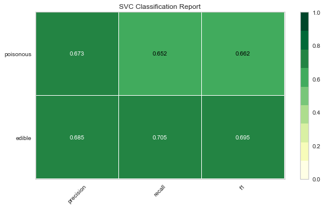

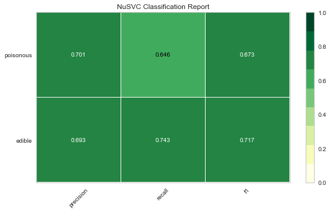

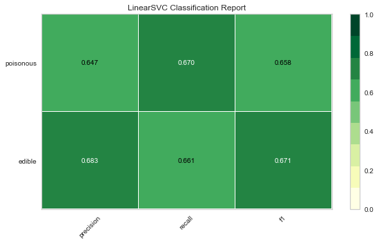

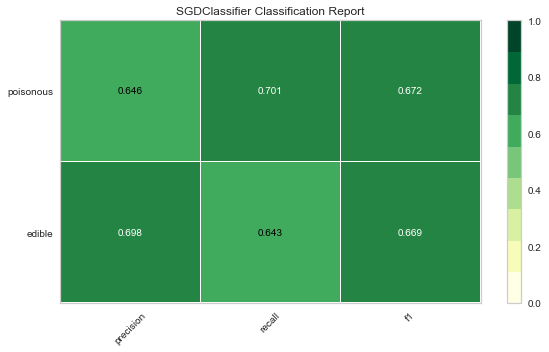

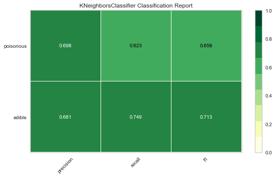

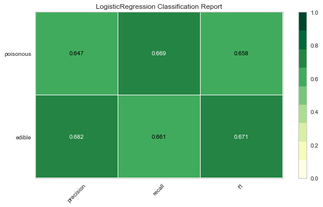

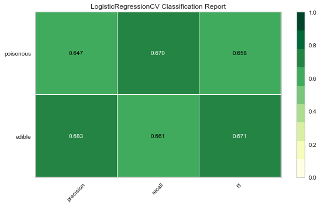

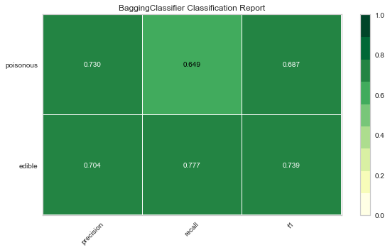

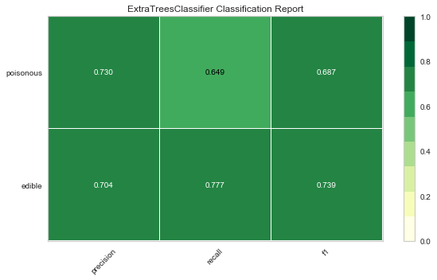

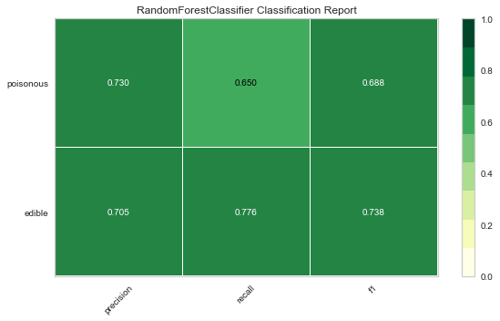

```python
for model in models:
    visualize_model(X, y, model)
```

1. Observer that `SGDClassifier` is great at predicting **poisonous** mushrooms
2. The `ExtraTreeClassifier` and `RandomForestClassifier` are better at prediciting editable mushrooms

## Conclusion

- Numerical scoring doesn't always tell the whole picture
- Visualization and Data Science go hand and hand.